# Introduction to R/Jupyter

This is a Jupyter Notebook. A Jupyter Notebook is an ["open-source web application that allows you to create and share documents that contain live code, equations, visualizations and narrative text."](http://jupyter.org) We will use the R programming languge and LaTex typsetting in Jupyter to prepare assignments and projects (you can also use other languages in Jupyter). The purpose of this note book is to familiarize yourself with programming in R.

R is a powerful open source programming language that is used for statistical computation and graphics. In many ways, it is similar to Matlab and Python (so, if you know these languages, learning R will be fairly easy!).

The best way to learn R and Jupyter is to jump right in! Below we walk through how to use Jupyter and R. **Text in boldface indicates exercises that I am asking you to complete.**

**This document was made as a general introduction to R programming and Jupyter notebooks. In the context of this course, it is an optional assignment that will not be graded or checked.**

```python
#This package will be used to autograde some of your answers
library(testthat)
```

## Part I: Basics

Jupyter has different types of cells. This cell is a "markdown" cell, and is used to write equations (LaTeX) and text. The other type of cell that we will use is a "code" cell. This is where we will program using R. You can create a new cell from the plus sign above (delete using the scissor) and select the type of cell using the drop down menu above and to the right.

Note:

1. In autograded assignments, don't add or delete cells. This will impact the autograder.
2. Here's a [LaTeX cheatsheet](http://wch.github.io/latexsheet/).

#### Double click on the "Type Markdown and LaTex: $a^2$" and type your favorite equation (come on, you know you have one...).

y=mx+b

In R/code cells, you can do (almost) anything that you can do in R, from basic computations to complex statistical modeling.

#### Create an R code cell below this cell. Compute the natural log of e. You may have guessed that the right functions for this are `log()` and `exp()`. But with R, you don't have to guess. You can type `?? log` to get some general information about functions related to logarithms (the same applies to other concepts); if you type "? X" you will get information about the specific function X (e.g., try `? exp`). Often, a Google search is a really effective way to learn about R functions.

```python
log(exp(1))
#fail() # No Answer - remove if you provide an answer
```

1

The function `c()` will allow you to create vectors ("c" for combine).

#### In the cell below, create three vectors:

1. a vector containing the numbers 1, 2, 5.3, 6, -2, 4;
2. a vector containing the strings "one", "two, and "three" (strings are formed in R by putting quotes around the words);
3. a vector of logicals: `TRUE`, `TRUE`, `FALSE`, `TRUE`.

```python
num_vec = c(1, 2, 5.3, 6, -2, 4)
str_vec = c('one', 'two', 'three')
log_vec = c(TRUE, TRUE, FALSE, TRUE)
#fail() # No Answer - remove if you provide an answer
```

#### Next, type `seq(1,10)` in the R cell below. What does it do? What about `seq(1, 20, by = 2)`? `seq(10, 20, len = 100)`? Why are these convenient?

```python
seq(10,20,len=100)
#YOUR CODE HERE
#fail() # No Answer - remove if you provide an answer
```

1. 10

2. 10.1010101010101

3. 10.2020202020202

4. 10.3030303030303

5. 10.4040404040404

6. 10.5050505050505

7. 10.6060606060606

8. 10.7070707070707

9. 10.8080808080808

10. 10.9090909090909

11. 11.010101010101

12. 11.1111111111111

13. 11.2121212121212

14. 11.3131313131313

15. 11.4141414141414

16. 11.5151515151515

17. 11.6161616161616

18. 11.7171717171717

19. 11.8181818181818

20. 11.9191919191919

21. 12.020202020202

22. 12.1212121212121

23. 12.2222222222222

24. 12.3232323232323

25. 12.4242424242424

26. 12.5252525252525

27. 12.6262626262626

28. 12.7272727272727

29. 12.8282828282828

30. 12.9292929292929

31. 13.030303030303

32. 13.1313131313131

33. 13.2323232323232

34. 13.3333333333333

35. 13.4343434343434

36. 13.5353535353535

37. 13.6363636363636

38. 13.7373737373737

39. 13.8383838383838

40. 13.9393939393939

41. 14.040404040404

42. 14.1414141414141

43. 14.2424242424242

44. 14.3434343434343

45. 14.4444444444444

46. 14.5454545454545

47. 14.6464646464646

48. 14.7474747474747

49. 14.8484848484848

50. 14.9494949494949

51. 15.0505050505051

52. 15.1515151515152

53. 15.2525252525253

54. 15.3535353535354

55. 15.4545454545455

56. 15.5555555555556

57. 15.6565656565657

58. 15.7575757575758

59. 15.8585858585859

60. 15.959595959596

61. 16.0606060606061

62. 16.1616161616162

63. 16.2626262626263

64. 16.3636363636364

65. 16.4646464646465

66. 16.5656565656566

67. 16.6666666666667

68. 16.7676767676768

69. 16.8686868686869

70. 16.969696969697

71. 17.0707070707071

72. 17.1717171717172

73. 17.2727272727273

74. 17.3737373737374

75. 17.4747474747475

76. 17.5757575757576

77. 17.6767676767677

78. 17.7777777777778

79. 17.8787878787879

80. 17.979797979798

81. 18.0808080808081

82. 18.1818181818182

83. 18.2828282828283

84. 18.3838383838384

85. 18.4848484848485

86. 18.5858585858586

87. 18.6868686868687

88. 18.7878787878788

89. 18.8888888888889

90. 18.989898989899

91. 19.0909090909091

92. 19.1919191919192

93. 19.2929292929293

94. 19.3939393939394

95. 19.4949494949495

96. 19.5959595959596

97. 19.6969696969697

98. 19.7979797979798

99. 19.8989898989899

100. 20

#### What does the `rep()` function do? This function can take in several arguments. To see what they are, use the help file! Explore the arguments `times` and `each`. What do they do?

```python
rep(str_vec, times=3, each=2)
#fail() # No Answer - remove if you provide an answer
```

1. 'one'

2. 'one'

3. 'two'

4. 'two'

5. 'three'

6. 'three'

7. 'one'

8. 'one'

9. 'two'

10. 'two'

11. 'three'

12. 'three'

13. 'one'

14. 'one'

15. 'two'

16. 'two'

17. 'three'

18. 'three'

You can store vectors in R using ${\tt =}$ or ${\tt <-}$.

#### Store the numbers 1 through 5 in a vector `v1`. Create another vector, `v2`, and join it together in a new vector, `new`.

*Note: This will be an autograded answer. The autograder will check whether you store the correct values in `v1`*.

```python
#assign 1, 2, 3, 4, 5 to the variable v1
v1 = seq(1,5)
#fail() # No Answer - remove if you provide an answer

#accessing data stored in variable v1
v1
#create two vectors, then join them together in a new vector
v2 = c(9, 10, 1)
new = c(v1, v2)
new
```

1. 1

2. 2

3. 3

4. 4

5. 5

1. 1

2. 2

3. 3

4. 4

5. 5

6. 9

7. 10

8. 1

```python
# Test Cell
```

Factors, also known as categorical/qualitative variables, are important in statistics. "Shoe color" (Black, Brown, etc.), "drink size" (S, M, L) and "espresso roast" (Light, Medium, Dark) are examples of factors. Below, in `f1`, create a factor with six groups, labeled 1 through 6 using the `factor()` and `rep()` functions; note that R treats these values as factors; so, for example, you can't multiply `f1` by a number. Try multiplying `f1` by 3...

```python
f1 = factor(seq(1,6))
#fail() # No Answer - remove if you provide an answer

f1
f2 = factor(c("a",7,"blue", "blue"))
f2

f1*3
```

1. 1

2. 2

3. 3

4. 4

5. 5

6. 6

**Levels**:**

1. '1'

2. '2'

3. '3'

4. '4'

5. '5'

6. '6'

1. a

2. 7

3. blue

4. blue

**Levels**:**

1. '7'

2. 'a'

3. 'blue'

1. <NA>

2. <NA>

3. <NA>

4. <NA>

5. <NA>

6. <NA>

```python
# Test Cell
```

#### In the code cell below, I've written several commonly used functions. Explore. Change/add some arguments. See the power of R!

Note that the first function creates (pseudo) random numbers from a normal distribution. Don't worry if you don't know what that is yet; we'll learn about it. But R can generate random numbers...that's cool!

50

257.502421731474

5.15004843462949

0.867158912774147

0.931213677291172

5.29457082279729

1. 2.72978261314001

2. 7.17211684487404

1. 1.5394974436082

2. 1.30117610540713

3. 1.72908284175016

4. 1.66708756793947

5. 1.82789020792278

6. 1.59735626060253

7. 1.48690955934066

8. 1.79998164838688

9. 1.91597194372882

10. 1.33069898457173

11. 1.72060940478113

12. 1.57852529197192

13. 1.90283957045406

14. 1.82657089474144

15. 1.57216943719047

16. 1.67857830096382

17. 1.6892708682873

18. 1.32678475000135

19. 1.84366787787675

20. 1.39839904597035

21. 1.00422197713988

22. 1.76480829463623

23. 1.62672004473715

24. 1.86531351992241

25. 1.58686950977339

26. 1.68154493980107

27. 1.50689364623082

28. 1.58414206625054

29. 1.6881678975163

30. 1.5033024885458

31. 1.8306575978475

32. 1.55338331123209

33. 1.35908836295391

34. 1.6367025479822

35. 1.97020084742195

36. 1.79467342830983

37. 1.70853202608465

38. 1.70970416551813

39. 1.72251586320896

40. 1.73952078157614

41. 1.69030399031954

42. 1.56944086990549

43. 1.31394596897326

44. 1.66627611239011

45. 1.59190799152306

46. 1.73381481116057

47. 1.60263507433933

48. 1.40276661608024

49. 1.25998998996033

50. 1.68121583366353

```
   Min. 1st Qu.  Median    Mean 3rd Qu.    Max.
  2.730   4.679   5.295   5.150   5.656   7.172
```

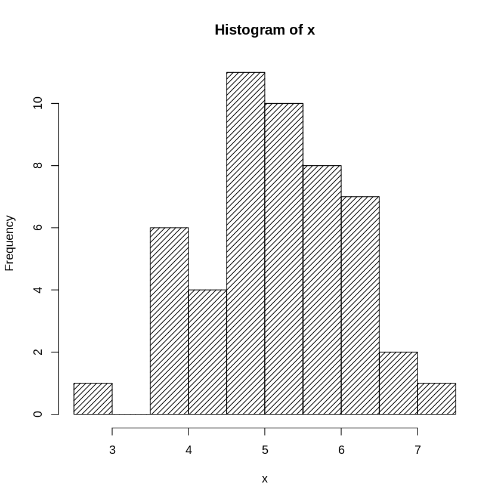

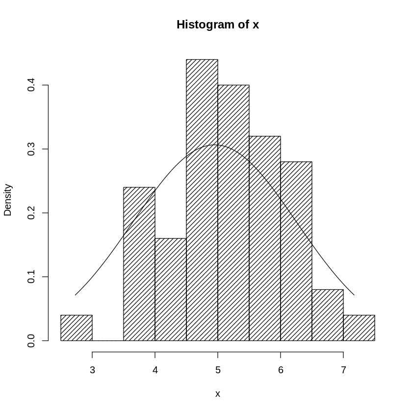

```python
x <- rnorm(50, mean=5, sd=1) #generates 50 random numbers from a gaussian with mean 5 and sd 1. Don't worry...you'll know what this means soon!
hist(x, density = 20)
length(x) #return the length of x
sum(x) #sum the numbers in x
mean(x) #calculate the mean of the numbers in x
var(x) #calculate the variance of the numbers in x
sd(x) #calculate the standard deviation of x
median(x) #calculate the median of x
range(x) #calculate the range of x
log(x) #calculate the natural log of x
summary(x) #return 5-number summary of x

hist(x, density = 20, freq = FALSE) #histogram of those random numbers; freq = FALSE makes x a 'density' (integrates to 1); density shades the boxes
curve(dnorm(x,mean = mean(x),sd = sd(x)),from = min(x), to = max(x), add = TRUE) #overlay of normal density
```

# Part II: Vector Indexing

R (like Matlab and Python) has a nice indexing system. Given a matrix $A$, we can access the $[i,j]$ element of $A$ by writing `A[i,j]`. We can access the $i^{th}$ row by typing `A[i,]`. And, we can access the $j^{th}$ column by typing `A[,j]`. And, we can do even fancier things too...

#### Modify the third line of code below to access the second, fourth, and sixth elements of the vector `a`. Take note of whether R starts indexing at 0 or 1! Also, note that the last line uses the minus sign to access elements *other than* those specified in the index.

```python
a = seq(2, 16, by = 2)
a
a[c(2, 4, 6)]

###
a[-c(1,5)]
```

1. 2

2. 4

3. 6

4. 8

5. 10

6. 12

7. 14

8. 16

1. 4

2. 8

3. 12

1. 4

2. 6

3. 8

4. 12

5. 14

6. 16

#### Write code that prints the third through sixth elements of `a` and store it in a variable `b` (there's a short and long way).

```python
b = a[seq(3,6)]
b
#fail() # No Answer - remove if you provide an answer
```

1. 6

2. 8

3. 10

4. 12

```python
# Test Cell
```

Logical indexing is another powerful tool for working with data in R.

#### Let's start with typing things like `a > 10`, `a <= 4`, `a == 10`, and `a != 10`. What do these lines do?

```python
a != 10
#fail() # No Answer - remove if you provide an answer
```

1. TRUE

2. TRUE

3. TRUE

4. TRUE

5. FALSE

6. TRUE

7. TRUE

8. TRUE

Now let's look at more complicated logical statements. Note that ${\tt \&}$ represents "and", and ${\tt |}$ represents "or" in R.

#### Write code that prints ${\tt TRUE}$ for values of $a$ greater than 6 and less than or equal to 10, and ${\tt FALSE}$ otherwise. Then, write code that prints ${\tt TRUE}$ for values of $a$ less than or equal to 4 or greater or equal to 12, and ${\tt FALSE}$ otherwise.

```python
a > 6 & a <= 10
#fail() # No Answer - remove if you provide an answer
```

1. FALSE

2. FALSE

3. FALSE

4. TRUE

5. TRUE

6. FALSE

7. FALSE

8. FALSE

#### Write code to print elements of `a` equal to 10. Then, print elements of `a` less than six or equal to 10.

```python
a[a == 10]
a[a < 6 | a == 10]
#fail() # No Answer - remove if you provide an answer
```

10

1. 2

2. 4

3. 10

## Part III: Functions, Loops and Beyond!

As we've seen, R has many built in functions; but, you can write your own, too! Below is the syntax.

#### Write a function that concatenates two vectors.

```python
y = function(v1, v2){
    output = c(v1, v2)
    return(output)
}

y(c(1,2,3), c(8,9))
#fail() # No Answer - remove if you provide an answer
```

1. 1

2. 2

3. 3

4. 8

5. 9

The function f1 below produces results like 'T' 'H' 'T' 'T'. We can think of `f1` a function that flips a coin four times.

#### Write a function `f2` that can be interpreted as rolling a fair die eight times. How could you modify the code to roll a biased die?

#### Notice that every time you run these function, the results are different! Uncomment the line `set.seed(99)` and notice what happens.

```python
#set.seed(99)
f1 = function(){
    s = sample(c("H", "T"), size = 4, replace = TRUE)
    return(s)
}

f1()

f2 = function(){
    s = sample(c(1,2,3,4,5,6,6,6,6), size = 8, replace = TRUE)
    return(s)
}

f2()
```

1. 'H'

2. 'T'

3. 'T'

4. 'H'

1. 4

2. 6

3. 2

4. 4

5. 6

6. 3

7. 5

8. 6

In R, just like in C++, Matlab, Python, etc., you can write loops to repeat a sequence of instructions until a certain condition is met.

#### Below is the syntax for a loop. Inside the loop, write a line of code that populates the matrix `M` with the numbers 1 through 20.

```python
n = 20;
M = matrix(NA, ncol = 2, nrow = 10); #check the help file so that you know what this does!

for (i in 1:n){
    M[i] = i
    #fail() # No Answer - remove if you provide an answer
}
M
```

A matrix: 10 × 2 of type int

| 1 | 11 |
| --- | --- |
| 2 | 12 |
| 3 | 13 |
| 4 | 14 |
| 5 | 15 |
| 6 | 16 |
| 7 | 17 |
| 8 | 18 |
| 9 | 19 |
| 10 | 20 |

#### Now, write a loop to calculate the mean of each column of `M`.

```python
m = matrix(NA, nrow = 2, ncol = 1)
for (i in 1:2){
    m[i] = mean(M[,i])
    #fail() # No Answer - remove if you provide an answer
}
m
colMeans(M)
```

A matrix: 2 × 1 of type dbl

| 5.5 |
| --- |
| 15.5 |

1. 5.5

2. 15.5

### Here's an incredibly important lesson about R: many tasks that require loops in other languages (e.g., C++) *do not* require loops in R.

#### As an example, use the function `colMeans()` to calculate the means of the columns of `M` without a loop. Store these means in a variable `M_means`. Then, look at the help file for `colMeans()` to see related functions.

```python
M_means = colMeans(M)
M_means
#fail() # No Answer - remove if you provide an answer
```

1. 5.5

2. 15.5

```python
# Test Cell
```

Note that the family of functions that includes `colMeans()` does not include a function to calculate the standard deviation or variance of a column (or row). But we can still do this without loops, using the `apply()` function.

**Below, the `apply()` function is set up to calculate the variance of each row of M. Modify the code to calculate the standard deviation of each column of M. Store your answer in `col_sd`.**

```python
apply(M, 1, var)
col_sd = apply(M, 2, sd)
col_sd
#fail() # No Answer - remove if you provide an answer
```

1. 50

2. 50

3. 50

4. 50

5. 50

6. 50

7. 50

8. 50

9. 50

10. 50

1. 3.02765035409749

2. 3.02765035409749

```python
# Test Cell
```

Recall above that we wrote a function `f1` that flips a coin four times. As odd as it sounds, it will become desirable for us to repeat many times (say, $m$ times) the process of flipping a coin four times. The result might be a matrix with $m$ rows and four columns.

#### Write a loop to repeat the process of "flipping a coin four times" 10,000 times. The result should be a 10,000 by 4 matrix.

```python
num = 10000
m = matrix(NA, nrow = num, ncol = 4)
for (i in 1:num){
    m[i,] = f1()
}
m
#fail() # No Answer - remove if you provide an answer
```

A matrix: 10000 × 4 of type chr

| T | T | H | H |
| --- | --- | --- | --- |
| H | T | T | H |
| H | H | T | H |
| H | T | H | T |
| T | H | H | H |
| H | T | H | T |
| H | H | H | T |
| H | T | H | T |
| H | T | T | T |
| H | H | T | T |
| T | H | T | T |
| H | H | T | H |
| H | H | H | T |
| T | T | H | H |
| H | H | H | T |
| H | H | T | T |
| H | T | T | T |
| H | H | T | H |
| H | T | T | H |
| T | H | T | H |
| H | T | T | T |
| H | H | H | H |
| H | T | T | T |
| T | H | T | T |
| H | T | H | T |
| T | H | H | T |
| H | H | T | H |
| H | T | T | H |
| T | H | T | H |
| H | H | T | H |
| ⋮ | ⋮ | ⋮ | ⋮ |
| T | H | H | T |
| H | T | T | T |
| T | T | H | T |
| H | H | T | H |
| H | H | H | T |
| T | H | H | T |
| T | H | T | T |
| H | T | T | H |
| H | H | H | H |
| T | T | H | H |
| H | T | T | T |
| T | T | H | H |
| T | T | T | T |
| T | H | T | T |
| T | H | H | H |
| H | H | H | H |
| H | T | T | H |
| T | T | H | T |
| T | T | H | T |
| H | H | T | H |
| T | H | H | T |
| H | T | H | H |
| T | H | H | T |
| T | T | H | H |
| H | T | H | T |
| T | T | T | H |
| H | T | H | T |
| H | H | H | T |
| H | H | T | T |
| H | H | H | T |

But, as master R programmers, we avoid loops whenever possible. One reason why we do this is because loops are slower than the fancy R alternatives. As an alternative to the loop above, let's use the `replicate()` function to repeat the coin flipping process.

#### Using the help function as your guide, use `replicate()` to repeat the process of "flipping a coin four times" 10,000 times.

```python
j = replicate(10000, f1())
j
#fail() # No Answer - remove if you provide an answer
```

A matrix: 4 × 10000 of type chr

| T | T | T | H | T | T | T | H | T | T | ⋯ | T | T | T | H | H | T | T | T | H | H |
| --- | --- | --- | --- | --- | --- | --- | --- | --- | --- | --- | --- | --- | --- | --- | --- | --- | --- | --- | --- | --- |
| T | H | H | T | T | H | H | H | T | T | ⋯ | T | H | T | H | T | T | T | H | H | H |
| T | T | T | H | T | T | H | T | H | H | ⋯ | T | T | T | H | H | T | H | H | H | H |
| H | T | H | T | H | T | H | T | H | T | ⋯ | T | H | T | T | H | T | T | T | T | H |

## Part IV: Working with Data Frames

Datasets in R are stored as *data frames*. Data frames are just tables of data (vectors of data of equal length). It will be important for future assignments (and in life!) for you to be able to work with data frames.

#### Take the vectors below and store them in a data frame, called `mydataframe`, using the function `data.frame()`.

```python
d = c(1, 2, 3, 4)
e = c("red", "white", "blue", NA)
f = c(TRUE, TRUE, TRUE, FALSE)

mydataframe = data.frame(d,e,f)
mydataframe
#fail() # No Answer - remove if you provide an answer
```

A data.frame: 4 × 3

| d <dbl> | e <fct> | f <lgl> |
| --- | --- | --- |
| 1 | red | TRUE |
| 2 | white | TRUE |
| 3 | blue | TRUE |
| 4 | NA | FALSE |

Note that the names of the columns aren't informative (they are just the names of the vectors used to create that dataframe). We can change that...

```python
#rename columns of data frame
names(mydataframe) = c("ID", "Color", "Passed")
mydataframe

#name columns while creating data frame
dataframe2 = data.frame(ID=d, Color=e, Passed=f)
dataframe2
```

A data.frame: 4 × 3

| ID <dbl> | Color <fct> | Passed <lgl> |
| --- | --- | --- |
| 1 | red | TRUE |
| 2 | white | TRUE |
| 3 | blue | TRUE |
| 4 | NA | FALSE |

A data.frame: 4 × 3

| ID <dbl> | Color <fct> | Passed <lgl> |
| --- | --- | --- |
| 1 | red | TRUE |
| 2 | white | TRUE |
| 3 | blue | TRUE |
| 4 | NA | FALSE |

There are a few ways that you can access elements of a dataframe.

1. You can access columns of a dataframe by typing `mydataframe$NameOfColumn` or by typing `mydataframe[ ,i]` (the latter will print the $i^{th}$ column).
2. To access the $i^{th}$ row, type `mydataframe[i, ]`.
3. To access the $[i,j]$ element, type `mydataframe[i,j]`. Note that data frames are indexed just like matrices: [row, column].

**Print the `Color` column of the dataframe from above in two different ways. Print the second row. Print the element containing "white".**

```python
mydataframe$Color
mydataframe[,2]
mydataframe[2,2]
#fail() # No Answer - remove if you provide an answer
```

1. red

2. white

3. blue

4. <NA>

**Levels**:**

1. 'blue'

2. 'red'

3. 'white'

1. red

2. white

3. blue

4. <NA>

**Levels**:**

1. 'blue'

2. 'red'

3. 'white'

white

**Levels**:**

1. 'blue'

2. 'red'

3. 'white'

You can save a dataframe using the function `write.table()`.

#### Below, I give code to save `mydataframe` in a location on my computer. Modify the code to save it somewhere on your computer. I would take this time to think about being organized with your files for this course!

Notice the `sep` argument is set to `"\t"`. This saves the file as a tab separated file. Look at the help file to see other options here.

```python
###Writing data to file
write.table(mydataframe, "example.txt", sep = "\t")
```

Now, let's read the file you saved back into R (this is going to be important for homework assignments!).

**Modify the code below to read your file back into R. Investigate what the `header` argument is doing!**

Note that the `head()` function prints the first few rows of your data frame. This can be helpful when you want to see how your data are organized, but don't want to print the whole thing.

```python
data = read.table("example.txt", header = TRUE, sep = "\t")
head(data)
```

A data.frame: 4 × 3

|  | ID <int> | Color <fct> | Passed <lgl> |
| --- | --- | --- | --- |
| 1 | 1 | red | TRUE |
| 2 | 2 | white | TRUE |
| 3 | 3 | blue | TRUE |
| 4 | 4 | NA | FALSE |

# Part V: Real-World Data Example

Let's explore a [dataset](https://dasl.datadescription.com/datafile/amazon-books/?_sfm_methods=Multiple+Regression&_sfm_cases=4+59943) about book prices from Amazon. The data consists of data on $n = 325$ books and includes measurements of:

- `aprice`: The price listed on Amazon (dollars)
- `lprice`: The book's list price (dollars)
- `weight`: The book's weight (ounces)
- `pages`: The number of pages in the book
- `height`: The book's height (inches)
- `width`: The book's width (inches)
- `thick`: The thickness of the book (inches)
- `cover`: Whether the book is a hard cover of paperback.
- And other variables...

First, we'll read this data in from Github...

```python
library(RCurl) #a package that includes the function getURL(), which allows for reading data from github.
library(ggplot2) #a package for nice plots!

#getURL is a nice way of reading in data from the web
url = getURL(paste0("https://raw.githubusercontent.com/bzaharatos/",
                    "-Statistical-Modeling-for-Data-Science-Applications/",
                    "master/Modern%20Regression%20Analysis%20/Datasets/amazon.txt"))
#stores the data in the dataframe amazon
amazon = read.csv(text = url, sep = "\t")

#prints the names in the dataframe
names(amazon)
```

1. 'Title'

2. 'Author'

3. 'List.Price'

4. 'Amazon.Price'

5. 'Hard..Paper'

6. 'NumPages'

7. 'Publisher'

8. 'Pub.year'

9. 'ISBN.10'

10. 'Height'

11. 'Width'

12. 'Thick'

13. 'Weight..oz.'

Next, let's create a new data frame, called `df`, and store a subset of the variables. In addition, we'll change the names of the variables in the dataframe to something cleaner and easier to work with. Take note of how to do this :)

```python
df = data.frame(aprice = amazon$Amazon.Price, lprice = as.numeric(amazon$List.Price),
                pages = amazon$NumPages, width = amazon$Width, weight = amazon$Weight..oz,
                height = amazon$Height, thick = amazon$Thick, cover = amazon$Hard..Paper)

summary(df)
```

```
     aprice           lprice           pages           width
 Min.   :  0.77   Min.   :  1.50   Min.   : 24.0   Min.   :4.100
 1st Qu.:  8.60   1st Qu.: 13.95   1st Qu.:208.0   1st Qu.:5.200
 Median : 10.20   Median : 15.00   Median :320.0   Median :5.400
 Mean   : 13.33   Mean   : 18.58   Mean   :335.9   Mean   :5.585
 3rd Qu.: 13.13   3rd Qu.: 19.95   3rd Qu.:416.0   3rd Qu.:5.900
 Max.   :139.95   Max.   :139.95   Max.   :896.0   Max.   :9.500
                  NA's   :1        NA's   :2       NA's   :5
     weight          height           thick        cover
 Min.   : 1.20   Min.   : 5.100   Min.   :0.1000   H: 89
 1st Qu.: 7.80   1st Qu.: 7.900   1st Qu.:0.6000   P:236
 Median :11.20   Median : 8.100   Median :0.9000
 Mean   :12.49   Mean   : 8.163   Mean   :0.9077
 3rd Qu.:16.00   3rd Qu.: 8.500   3rd Qu.:1.1000
 Max.   :35.20   Max.   :12.100   Max.   :2.1000
 NA's   :9       NA's   :4        NA's   :1
```

From the summary, we can see that there are missing values in the dataset, coded as `NA`. There are many ways to deal with missing data. Suppose that sample unit $i$ has a missing measurement for variable $z_j$. We could:

1. Delete sample unit $i$ from the dataset, i.e., delete the entire row. That might be reasonable if there are very view missing values and if we think the values are missing at random.
2. Delete the variable $z_j$ from the dataset, i.e., delete the entire column. This might be reasonable if there are many many other missing values for $z_j$ and if we think $z_j$ might not be neccesary for our overall prediction/explanation goals.
3. Impute missing values by substituting each missing value with an estimate.

For more information on missing values, see this [resource](https://www.bu.edu/sph/files/2014/05/Marina-tech-report.pdf).

```python
which(is.na(df$lprice))
```

205

```python
df[205,2] = mean(df$lprice, na.rm=TRUE)
summary(df)
```

```
     aprice           lprice           pages           width
 Min.   :  0.77   Min.   :  1.50   Min.   : 24.0   Min.   :4.100
 1st Qu.:  8.60   1st Qu.: 13.95   1st Qu.:208.0   1st Qu.:5.200
 Median : 10.20   Median : 15.00   Median :320.0   Median :5.400
 Mean   : 13.33   Mean   : 18.58   Mean   :335.9   Mean   :5.585
 3rd Qu.: 13.13   3rd Qu.: 19.95   3rd Qu.:416.0   3rd Qu.:5.900
 Max.   :139.95   Max.   :139.95   Max.   :896.0   Max.   :9.500
                                   NA's   :2       NA's   :5
     weight          height           thick        cover
 Min.   : 1.20   Min.   : 5.100   Min.   :0.1000   H: 89
 1st Qu.: 7.80   1st Qu.: 7.900   1st Qu.:0.6000   P:236
 Median :11.20   Median : 8.100   Median :0.9000
 Mean   :12.49   Mean   : 8.163   Mean   :0.9077
 3rd Qu.:16.00   3rd Qu.: 8.500   3rd Qu.:1.1000
 Max.   :35.20   Max.   :12.100   Max.   :2.1000
 NA's   :9       NA's   :4        NA's   :1
```

#### Use the `summary()` function to print numerical summaries of this dataset.

```python
summary(df)
#fail() # No Answer - remove if you provide an answer
```

```
     aprice           lprice           pages           width
 Min.   :  0.77   Min.   :  1.50   Min.   : 24.0   Min.   :4.100
 1st Qu.:  8.60   1st Qu.: 13.95   1st Qu.:208.0   1st Qu.:5.200
 Median : 10.20   Median : 15.00   Median :320.0   Median :5.400
 Mean   : 13.33   Mean   : 18.58   Mean   :335.9   Mean   :5.585
 3rd Qu.: 13.13   3rd Qu.: 19.95   3rd Qu.:416.0   3rd Qu.:5.900
 Max.   :139.95   Max.   :139.95   Max.   :896.0   Max.   :9.500
                                   NA's   :2       NA's   :5
     weight          height           thick        cover
 Min.   : 1.20   Min.   : 5.100   Min.   :0.1000   H: 89
 1st Qu.: 7.80   1st Qu.: 7.900   1st Qu.:0.6000   P:236
 Median :11.20   Median : 8.100   Median :0.9000
 Mean   :12.49   Mean   : 8.163   Mean   :0.9077
 3rd Qu.:16.00   3rd Qu.: 8.500   3rd Qu.:1.1000
 Max.   :35.20   Max.   :12.100   Max.   :2.1000
 NA's   :9       NA's   :4        NA's   :1
```

#### Use the `sort()` function to order the`lprice` variable from lowest to highest. Remember to use the `df` data frame!

```python
sort(df$lprice)
#fail() # No Answer - remove if you provide an answer
```

1. 1.5

2. 2

3. 3.95

4. 4.99

5. 4.99

6. 5.95

7. 5.99

8. 5.99

9. 5.99

10. 6.69

11. 6.95

12. 6.95

13. 6.95

14. 6.99

15. 6.99

16. 6.99

17. 6.99

18. 6.99

19. 6.99

20. 6.99

21. 6.99

22. 7.5

23. 7.75

24. 7.77

25. 7.95

26. 7.95

27. 7.95

28. 7.95

29. 7.99

30. 7.99

31. 7.99

32. 8

33. 8.42

34. 8.95

35. 8.95

36. 8.95

37. 8.99

38. 8.99

39. 8.99

40. 8.99

41. 8.99

42. 8.99

43. 9.95

44. 9.99

45. 9.99

46. 9.99

47. 9.99

48. 9.99

49. 9.99

50. 9.99

51. 9.99

52. 10.65

53. 10.95

54. 10.99

55. 11

56. 11

57. 11.5

58. 11.94

59. 11.99

60. 11.99

61. 12

62. 12

63. 12

64. 12

65. 12

66. 12.14

67. 12.6

68. 12.95

69. 12.95

70. 12.95

71. 12.99

72. 12.99

73. 13

74. 13

75. 13

76. 13

77. 13

78. 13.07

79. 13.29

80. 13.83

81. 13.95

82. 13.95

83. 13.95

84. 13.95

85. 13.95

86. 13.95

87. 13.99

88. 13.99

89. 13.99

90. 13.99

91. 13.99

92. 14

93. 14

94. 14

95. 14

96. 14

97. 14

98. 14

99. 14

100. 14

101. 14

102. 14

103. 14

104. 14

105. 14.1

106. 14.54

107. 14.95

108. 14.95

109. 14.95

110. 14.95

111. 14.95

112. 14.95

113. 14.95

114. 14.95

115. 14.95

116. 14.95

117. 14.95

118. 14.95

119. 14.95

120. 14.95

121. 14.95

122. 14.95

123. 14.95

124. 14.95

125. 14.95

126. 14.95

127. 14.99

128. 14.99

129. 14.99

130. 14.99

131. 14.99

132. 14.99

133. 14.99

134. 15

135. 15

136. 15

137. 15

138. 15

139. 15

140. 15

141. 15

142. 15

143. 15

144. 15

145. 15

146. 15

147. 15

148. 15

149. 15

150. 15

151. 15

152. 15

153. 15

154. 15

155. 15

156. 15

157. 15

158. 15

159. 15

160. 15

161. 15

162. 15

163. 15

164. 15

165. 15

166. 15

167. 15

168. 15

169. 15

170. 15.44

171. 15.95

172. 15.95

173. 15.95

174. 15.95

175. 15.95

176. 15.95

177. 15.95

178. 15.95

179. 15.95

180. 15.95

181. 15.95

182. 15.95

183. 15.99

184. 15.99

185. 15.99

186. 15.99

187. 16

188. 16

189. 16

190. 16

191. 16

192. 16

193. 16

194. 16

195. 16

196. 16

197. 16

198. 16

199. 16

200. 16

201. 16

202. 16

203. 16

204. 16

205. 16

206. 16

207. 16

208. 16.95

209. 16.95

210. 16.99

211. 16.99

212. 16.99

213. 16.99

214. 16.99

215. 16.99

216. 17

217. 17

218. 17

219. 17

220. 17

221. 17

222. 17

223. 17.95

224. 17.99

225. 17.99

226. 17.99

227. 17.99

228. 17.99

229. 17.99

230. 17.99

231. 17.99

232. 17.99

233. 17.99

234. 18

235. 18

236. 18

237. 18

238. 18.5797530864198

239. 18.95

240. 18.99

241. 18.99

242. 18.99

243. 19.73

244. 19.95

245. 19.95

246. 19.99

247. 20

248. 20

249. 20

250. 20

251. 20

252. 20

253. 20

254. 20

255. 20

256. 21

257. 21.1

258. 21.99

259. 22

260. 22

261. 22

262. 22.99

263. 24

264. 24

265. 24

266. 24.95

267. 24.95

268. 24.95

269. 24.99

270. 24.99

271. 24.99

272. 25

273. 25

274. 25

275. 25

276. 25

277. 25.05

278. 25.95

279. 26

280. 26

281. 26

282. 26

283. 26

284. 26.95

285. 26.95

286. 26.95

287. 26.95

288. 26.99

289. 26.99

290. 26.99

291. 26.99

292. 27

293. 27.55

294. 27.95

295. 27.99

296. 27.99

297. 28

298. 28

299. 28.95

300. 29.5

301. 30

302. 30

303. 30

304. 30

305. 30.5

306. 32.95

307. 34.8

308. 35

309. 35

310. 35.75

311. 35.75

312. 35.95

313. 37.5

314. 39.95

315. 39.95

316. 48.2

317. 48.2

318. 53.95

319. 70.8

320. 75

321. 86.95

322. 97.5

323. 98.95

324. 114.95

325. 139.95

#### Code the `cover` varible as a factor.

```python
as.factor(df$cover)
#fail() # No Answer - remove if you provide an answer
```

1. P

2. P

3. P

4. P

5. P

6. H

7. H

8. P

9. H

10. H

11. P

12. P

13. H

14. P

15. P

16. H

17. P

18. P

19. P

20. H

21. P

22. P

23. P

24. P

25. H

26. P

27. P

28. H

29. P

30. P

31. H

32. H

33. P

34. P

35. P

36. P

37. P

38. P

39. P

40. H

41. P

42. P

43. H

44. H

45. P

46. P

47. P

48. P

49. H

50. H

51. P

52. P

53. H

54. P

55. P

56. P

57. P

58. P

59. P

60. P

61. P

62. P

63. P

64. P

65. P

66. H

67. P

68. P

69. H

70. P

71. P

72. P

73. P

74. P

75. P

76. P

77. H

78. P

79. H

80. H

81. P

82. P

83. P

84. H

85. H

86. P

87. P

88. H

89. P

90. P

91. P

92. P

93. P

94. P

95. H

96. H

97. H

98. H

99. P

100. P

101. P

102. P

103. P

104. P

105. H

106. H

107. P

108. H

109. P

110. P

111. P

112. P

113. H

114. P

115. P

116. P

117. P

118. P

119. P

120. P

121. P

122. H

123. P

124. P

125. H

126. H

127. P

128. H

129. H

130. H

131. P

132. P

133. H

134. P

135. P

136. H

137. P

138. H

139. P

140. P

141. P

142. H

143. P

144. P

145. P

146. H

147. P

148. P

149. P

150. P

151. H

152. P

153. P

154. P

155. P

156. P

157. P

158. P

159. P

160. P

161. P

162. P

163. P

164. P

165. H

166. H

167. H

168. P

169. H

170. H

171. P

172. P

173. P

174. H

175. P

176. P

177. P

178. P

179. P

180. P

181. P

182. P

183. P

184. P

185. H

186. H

187. H

188. H

189. P

190. H

191. P

192. P

193. P

194. H

195. H

196. P

197. P

198. P

199. P

200. P

201. P

202. P

203. P

204. P

205. P

206. P

207. P

208. P

209. P

210. P

211. P

212. P

213. P

214. H

215. H

216. P

217. P

218. P

219. P

220. P

221. H

222. H

223. P

224. P

225. P

226. P

227. P

228. P

229. H

230. P

231. P

232. P

233. P

234. H

235. H

236. P

237. P

238. P

239. H

240. P

241. P

242. H

243. H

244. P

245. P

246. H

247. P

248. P

249. P

250. P

251. P

252. H

253. P

254. P

255. P

256. P

257. P

258. P

259. P

260. H

261. P

262. H

263. P

264. H

265. P

266. P

267. P

268. P

269. P

270. P

271. P

272. P

273. P

274. P

275. H

276. P

277. H

278. P

279. P

280. P

281. P

282. P

283. P

284. P

285. H

286. P

287. P

288. H

289. P

290. H

291. P

292. H

293. P

294. P

295. H

296. P

297. P

298. H

299. H

300. H

301. P

302. P

303. P

304. P

305. P

306. H

307. H

308. H

309. P

310. P

311. P

312. P

313. P

314. H

315. H

316. P

317. P

318. P

319. P

320. P

321. H

322. P

323. P

324. P

325. P

**Levels**:**

1. 'H'

2. 'P'

#### Note that you could provide more descriptive labels for the levels of this factor (note that `H` = "Hardcover" and `P` = "Paperback"). The easiest way do do this is with the `levels()` function: `levels(x) = value`.

```python
levels(df$cover) = c("Hardcover","Paperback")
summary(df)
```

```
     aprice           lprice           pages           width
 Min.   :  0.77   Min.   :  1.50   Min.   : 24.0   Min.   :4.100
 1st Qu.:  8.60   1st Qu.: 13.95   1st Qu.:208.0   1st Qu.:5.200
 Median : 10.20   Median : 15.00   Median :320.0   Median :5.400
 Mean   : 13.33   Mean   : 18.58   Mean   :335.9   Mean   :5.585
 3rd Qu.: 13.13   3rd Qu.: 19.95   3rd Qu.:416.0   3rd Qu.:5.900
 Max.   :139.95   Max.   :139.95   Max.   :896.0   Max.   :9.500
                                   NA's   :2       NA's   :5
     weight          height           thick              cover
 Min.   : 1.20   Min.   : 5.100   Min.   :0.1000   Hardcover: 89
 1st Qu.: 7.80   1st Qu.: 7.900   1st Qu.:0.6000   Paperback:236
 Median :11.20   Median : 8.100   Median :0.9000
 Mean   :12.49   Mean   : 8.163   Mean   :0.9077
 3rd Qu.:16.00   3rd Qu.: 8.500   3rd Qu.:1.1000
 Max.   :35.20   Max.   :12.100   Max.   :2.1000
 NA's   :9       NA's   :4        NA's   :1
```

#### Print a histogram of the `pages` variable. Comment on it's shape.

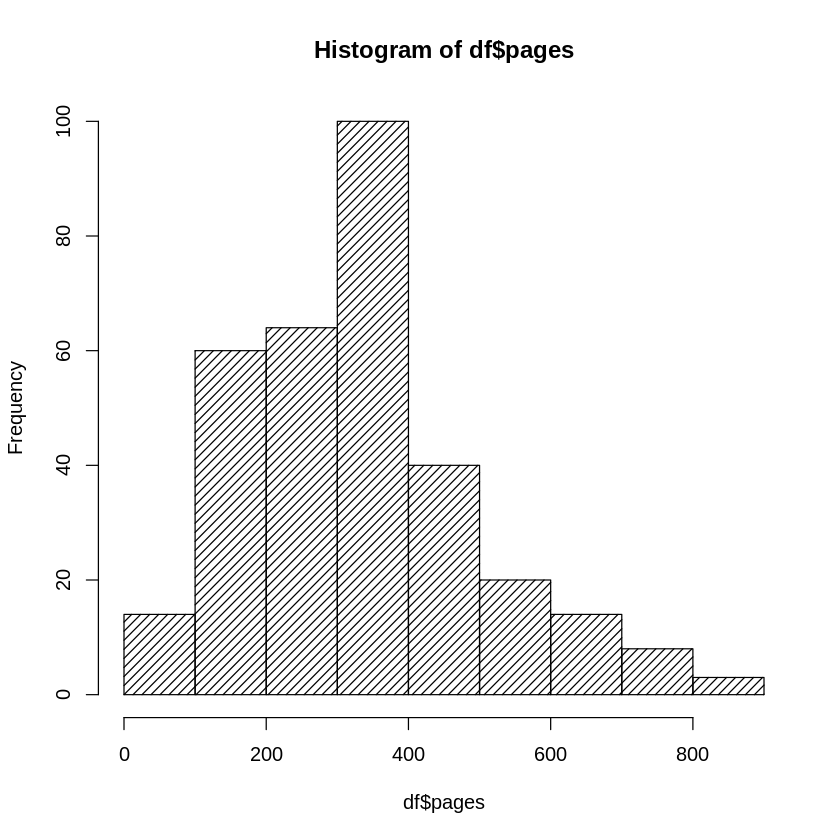

```python
hist(df$pages, density = 20)
#fail() # No Answer - remove if you provide an answer
```

This is a right skewed distribution.

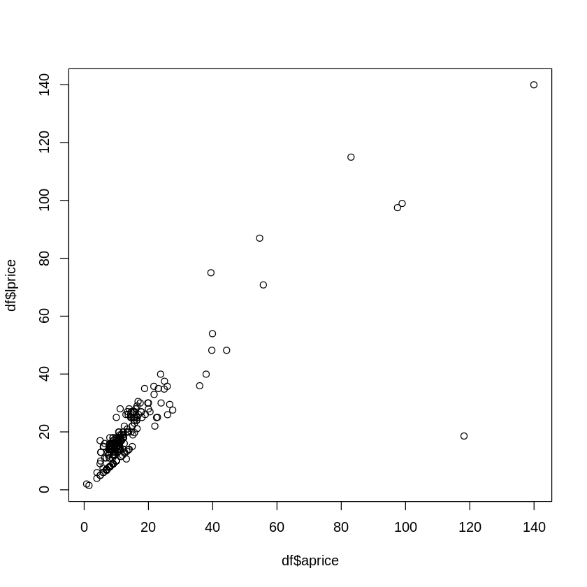

```python
plot(df$aprice, df$lprice)
#fail() # No Answer - remove if you provide an answer
```

The variables appear to be correlated.

#### Use the `boxplot()` function to produce a boxplot of `pages` conditioned on `cover`. Interpret this plot.

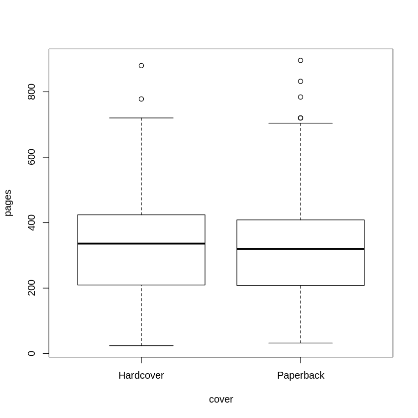

```python
boxplot(pages~cover,data=df)
#fail() # No Answer - remove if you provide an answer
```

There isn't a noticable difference in page length between books that are hardcover and paperback.

Note another way to read data from the web...

```python
### Reading data from the web...
read.table("http://www.stats.ox.ac.uk/pub/datasets/csb/ch11b.dat")
```

[output not shown]